# Exploratory Data Analysis Using Python

OBJECTIVE

This project aims to analyze a dataset containing information about freelancing jobs and provide valuable insights into the freelancing market. The dataset includes details such as job titles, categories, experience levels, budgets, client information, and posting dates. By conducting exploratory data analysis, this project uncovers patterns and trends within the dataset, helping stakeholders make informed decisions and better understand the freelancing landscape.

INTRODUCTION

The rise of freelancing has transformed the way people work, offering flexible opportunities and a global talent pool. However, navigating the freelancing market can be challenging due to the vast amount of data available. This project focuses on analyzing a comprehensive dataset of freelancing jobs to gain insights into various aspects of the market.

Feature Description

The dataset for this project consists of the following features:

1. Title: The title of the job posting.
2. Category Name: The category to which the job belongs.
3. Experience: The required level of experience for the job.
4. Sub Category Name: The sub-category to which the job belongs.
5. Currency: The currency in which the budget is specified.
6. Budget: The budget allocated for the job.
7. Location: The location where the job is based.
8. Freelancer Preferred From: The preferred location of the freelancer.
9. Type: The type of job (e.g., full-time, part-time, hourly).
10. Date Posted: The date when the job was posted.
11. Description: A description of the job.
12. Duration: The expected duration of the job (if specified).
13. Client Registration Date: The registration date of the client.
14. Client City: The city of the client.
15. Client Country: The country of the client.
16. Client Currency: The currency preferred by the client.
17. Client Job Title: The job title of the client (if specified).

Problem Statement

The project aims to address the following questions:

1. What are the most common job categories in the freelancing market?
2. How do experience levels vary across different locations?
3. Which categories have the highest and lowest budgets?
4. Which type of job most preferable?
5. What is the distribution of freelancing jobs across different locations?
6. Which countries have the highest number of job postings?
7. What is the budget distribution based on experience level?
8. Which Sub categories have the highest and lowest budgets?

# Import Libraries

```python
import pandas as pd
import numpy as np
import matplotlib.pyplot as plt
import seaborn as sns
```

# Load Data

```python
df=pd.read_csv('archive (2) (1).zip')
```

```python
df.head()   #gives top 5 values
```

|  | Title | Category Name | Experience | Sub Category Name | Currency | Budget | Location | Freelancer Preferred From | Type | Date Posted | Description | Duration | Client Registration Date | Client City | Client Country | Client Currency | Client Job Title |
| --- | --- | --- | --- | --- | --- | --- | --- | --- | --- | --- | --- | --- | --- | --- | --- | --- | --- |
| 0 | Banner images for web desgin websites | Design | Entry ($) | Graphic Design | EUR | 60.0 | remote | ALL | fixed_price | 2023-04-29 18:06:39 | We are looking to improve the banner images on... | NaN | 2010-11-03 | Dublin | Ireland | EUR | PPC Management |
| 1 | Make my picture a solid silhouette | Video, Photo & Image | Entry ($) | Image Editing | GBP | 20.0 | remote | ALL | fixed_price | 2023-04-29 17:40:28 | Hello \n\nI need a quick designer to make 4 pi... | NaN | 2017-02-21 | London | United Kingdom | GBP | Office manager |
| 2 | Bookkeeper needed | Business | Entry ($) | Finance & Accounting | GBP | 12.0 | remote | ALL | fixed_price | 2023-04-29 17:40:06 | Hi - I need a bookkeeper to assist with bookke... | NaN | 2023-04-09 | London | United Kingdom | GBP | Paralegal |
| 3 | Accountant needed | Business | Entry ($) | Tax Consulting & Advising | GBP | 14.0 | remote | ALL | fixed_price | 2023-04-29 17:32:01 | Hi - I need an accountant to assist me with un... | NaN | 2023-04-09 | London | United Kingdom | GBP | Paralegal |
| 4 | Guest Post on High DA Website | Digital Marketing | Expert ($$$) | SEO | USD | 10000.0 | remote | ALL | fixed_price | 2023-04-29 17:09:36 | Hi, I am currently running a project where I w... | NaN | 2016-07-01 | Mumbai | India | USD | Guest posts buyer |

```python
df.info()
# No of columns are 17
# No of rows are 12222
# Duration,Client Job Title contains null values
```

```
<class 'pandas.core.frame.DataFrame'>
RangeIndex: 12222 entries, 0 to 12221
Data columns (total 17 columns):
 #   Column                     Non-Null Count  Dtype
---  ------                     --------------  -----
 0   Title                      12222 non-null  object
 1   Category Name              12222 non-null  object
 2   Experience                 12222 non-null  object
 3   Sub Category Name          12222 non-null  object
 4   Currency                   12222 non-null  object
 5   Budget                     12222 non-null  float64
 6   Location                   12222 non-null  object
 7   Freelancer Preferred From  12222 non-null  object
 8   Type                       12222 non-null  object
 9   Date Posted                12222 non-null  object
 10  Description                12222 non-null  object
 11  Duration                   1602 non-null   object
 12  Client Registration Date   12222 non-null  object
 13  Client City                12222 non-null  object
 14  Client Country             12222 non-null  object
 15  Client Currency            12222 non-null  object
 16  Client Job Title           4588 non-null   object
dtypes: float64(1), object(16)
memory usage: 1.6+ MB
```

```python
print("shape of dataset",df.shape)
```

```
shape of dataset (12222, 17)
```

# Handling Missing Data

```python
df.isna().sum()
#Duration and Client Job Title columns has 10620,7634 null values respectively
```

```
Title                            0
Category Name                    0
Experience                       0
Sub Category Name                0
Currency                         0
Budget                           0
Location                         0
Freelancer Preferred From        0
Type                             0
Date Posted                      0
Description                      0
Duration                     10620
Client Registration Date         0
Client City                      0
Client Country                   0
Client Currency                  0
Client Job Title              7634
dtype: int64
```

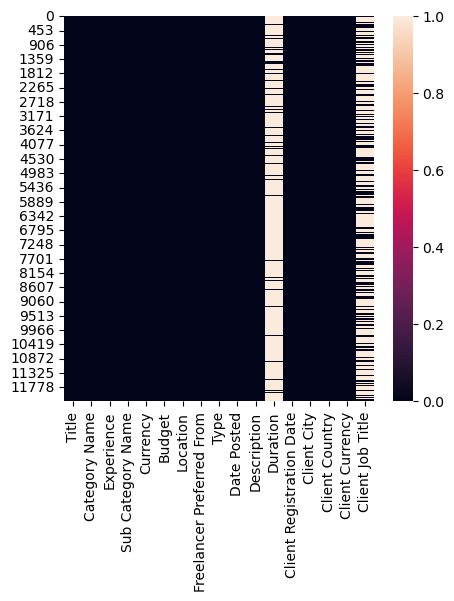

```python
#use of heatmap for visual representation of null values
import seaborn as sns
import matplotlib.pyplot as plt
plt.figure(figsize=(5,5))
sns.heatmap(df.isnull())
```

```python
#checking How much % of null value in that both column
df.isnull().sum()/len(df)*100
```

```
Title                         0.000000
Category Name                 0.000000
Experience                    0.000000
Sub Category Name             0.000000
Currency                      0.000000
Budget                        0.000000
Location                      0.000000
Freelancer Preferred From     0.000000
Type                          0.000000
Date Posted                   0.000000
Description                   0.000000
Duration                     86.892489
Client Registration Date      0.000000
Client City                   0.000000
Client Country                0.000000
Client Currency               0.000000
Client Job Title             62.461136
dtype: float64
```

```python
df.drop(columns=["Duration", "Client Job Title"], inplace=True)     #remove  columns
```

```python
print("new shape of data set",df.shape) #now  we have 15 column and 12222 rows
```

```
new shape of data set (12222, 15)
```

```python
df["Experience"].head()
```

```
0       Entry ($)
1       Entry ($)
2       Entry ($)
3       Entry ($)
4    Expert ($$$)
Name: Experience, dtype: object
```

```python
#remove unwanted symbols($,$$,$$$) from experience

df['Experience'] = df['Experience'].replace({'Entry ($)':'Entry', 'Intermediate ($$)': 'Intermediate','Expert ($$$)': 'Expert'})   # repalce value
df["Experience"].head()
```

```
0     Entry
1     Entry
2     Entry
3     Entry
4    Expert
Name: Experience, dtype: object
```

```python
#conevert all Budget Value in one currency i.e "USD"

def Budget_USD(row):
    if row['Currency'] == 'EUR':
        return row['Budget'] * 1.0956
    elif row['Currency'] == 'GBP':
        return row['Budget'] * 1.28
    else:
        return row['Budget']
```

```python
df['Budget'] = df.apply(Budget_USD, axis=1)
```

```python
df['Budget'].head()
```

```
0       65.736
1       25.600
2       15.360
3       17.920
4    10000.000
Name: Budget, dtype: float64
```

```python
df['Currency'] = df['Currency'].replace({'EUR':'USD', 'GBP': 'USD',' USD':'USD'})
df['Currency'].nunique()
```

```
1
```

```python
df.head()
```

|  | Title | Category Name | Experience | Sub Category Name | Currency | Budget | Location | Freelancer Preferred From | Type | Date Posted | Description | Client Registration Date | Client City | Client Country | Client Currency |
| --- | --- | --- | --- | --- | --- | --- | --- | --- | --- | --- | --- | --- | --- | --- | --- |
| 0 | Banner images for web desgin websites | Design | Entry | Graphic Design | USD | 65.736 | remote | ALL | fixed_price | 2023-04-29 18:06:39 | We are looking to improve the banner images on... | 2010-11-03 | Dublin | Ireland | EUR |
| 1 | Make my picture a solid silhouette | Video, Photo & Image | Entry | Image Editing | USD | 25.600 | remote | ALL | fixed_price | 2023-04-29 17:40:28 | Hello \n\nI need a quick designer to make 4 pi... | 2017-02-21 | London | United Kingdom | GBP |
| 2 | Bookkeeper needed | Business | Entry | Finance & Accounting | USD | 15.360 | remote | ALL | fixed_price | 2023-04-29 17:40:06 | Hi - I need a bookkeeper to assist with bookke... | 2023-04-09 | London | United Kingdom | GBP |
| 3 | Accountant needed | Business | Entry | Tax Consulting & Advising | USD | 17.920 | remote | ALL | fixed_price | 2023-04-29 17:32:01 | Hi - I need an accountant to assist me with un... | 2023-04-09 | London | United Kingdom | GBP |
| 4 | Guest Post on High DA Website | Digital Marketing | Expert | SEO | USD | 10000.000 | remote | ALL | fixed_price | 2023-04-29 17:09:36 | Hi, I am currently running a project where I w... | 2016-07-01 | Mumbai | India | USD |

```python
df.describe() #statistical information of budget column
```

|  | Budget |
| --- | --- |
| count | 12222.000000 |
| mean | 272.077271 |
| std | 2345.979319 |
| min | 0.000000 |
| 25% | 38.400000 |
| 50% | 96.000000 |
| 75% | 192.000000 |
| max | 127998.720000 |

```python
import warnings
warnings.filterwarnings('ignore')
```

# Feature Extraction

```python
df[['Posted_day', 'Posted_time']] = df['Date Posted'].str.split(' ', 1, expand=True)
df[['Posted_day', 'Posted_time']]
```

|  | Posted_day | Posted_time |
| --- | --- | --- |
| 0 | 2023-04-29 | 18:06:39 |
| 1 | 2023-04-29 | 17:40:28 |
| 2 | 2023-04-29 | 17:40:06 |
| 3 | 2023-04-29 | 17:32:01 |
| 4 | 2023-04-29 | 17:09:36 |
| ... | ... | ... |
| 12217 | 2023-01-18 | 19:23:01 |
| 12218 | 2023-01-18 | 19:18:48 |
| 12219 | 2023-01-18 | 19:18:48 |
| 12220 | 2023-01-18 | 19:18:47 |
| 12221 | 2023-01-18 | 19:18:47 |

12222 rows × 2 columns

```python
df=df.drop(columns=['Date Posted',"Posted_time"])
```

```python
df[['Posted_year','Posted_Month','Posted_Date']]=df["Posted_day"].str.split('-', 3, expand=True)
```

```python
df[['Posted_year','Posted_Month','Posted_Date']]=df[['Posted_year','Posted_Month','Posted_Date']].astype('int32')
```

```python
df=df.drop(columns=["Posted_Date"])
```

```python
df[['client_year','client_Month','client_Date']]=df['Client Registration Date'].str.split('-', 3, expand=True)
```

```python
df[['client_year','client_Month','client_Date']]=df[['client_year','client_Month','client_Date']].astype('int32')
```

```python
df=df.drop(columns=['Client Registration Date','client_Date'])
```

```python
df.head()
```

|  | Title | Category Name | Experience | Sub Category Name | Currency | Budget | Location | Freelancer Preferred From | Type | Description | Client City | Client Country | Client Currency | Posted_day | Posted_year | Posted_Month | client_year | client_Month |
| --- | --- | --- | --- | --- | --- | --- | --- | --- | --- | --- | --- | --- | --- | --- | --- | --- | --- | --- |
| 0 | Banner images for web desgin websites | Design | Entry | Graphic Design | USD | 65.736 | remote | ALL | fixed_price | We are looking to improve the banner images on... | Dublin | Ireland | EUR | 2023-04-29 | 2023 | 4 | 2010 | 11 |
| 1 | Make my picture a solid silhouette | Video, Photo & Image | Entry | Image Editing | USD | 25.600 | remote | ALL | fixed_price | Hello \n\nI need a quick designer to make 4 pi... | London | United Kingdom | GBP | 2023-04-29 | 2023 | 4 | 2017 | 2 |
| 2 | Bookkeeper needed | Business | Entry | Finance & Accounting | USD | 15.360 | remote | ALL | fixed_price | Hi - I need a bookkeeper to assist with bookke... | London | United Kingdom | GBP | 2023-04-29 | 2023 | 4 | 2023 | 4 |
| 3 | Accountant needed | Business | Entry | Tax Consulting & Advising | USD | 17.920 | remote | ALL | fixed_price | Hi - I need an accountant to assist me with un... | London | United Kingdom | GBP | 2023-04-29 | 2023 | 4 | 2023 | 4 |
| 4 | Guest Post on High DA Website | Digital Marketing | Expert | SEO | USD | 10000.000 | remote | ALL | fixed_price | Hi, I am currently running a project where I w... | Mumbai | India | USD | 2023-04-29 | 2023 | 4 | 2016 | 7 |

# Analysis Of Data

```python
category_count=df["Category Name"].value_counts()
category_count
```

```
Design                         3634
Technology & Programming       3003
Writing & Translation          1387
Business                       1211
Video, Photo & Image            847
Digital Marketing               792
Marketing, Branding & Sales     708
Social Media                    433
Music & Audio                   207
Name: Category Name, dtype: int64
```

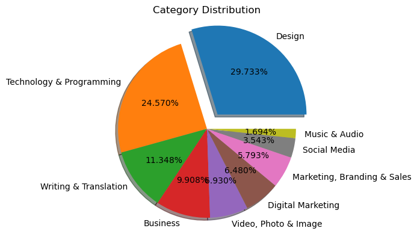

```python
ex=[0.2,0,0,0,0,0,0,0,0]
plt.pie(category_count,explode=ex,labels=category_count.index,autopct="%0.3f%%",shadow=True)
plt.title("Category Distribution")
plt.show()
```

From above graph we understand Design has highest and Music and Audio has lowest distribution

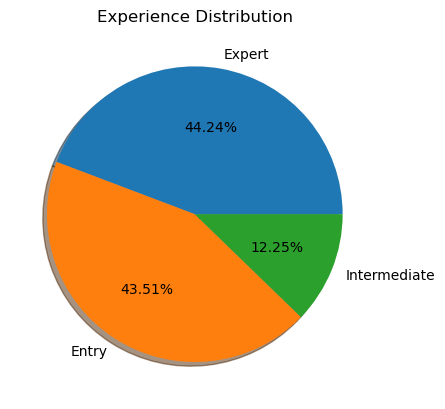

```python
Experience_count=df["Experience"].value_counts()

ex=[0,0,0]
plt.pie(Experience_count,explode=ex,labels=Experience_count.index,autopct="%0.2f%%",shadow=True)
plt.title("Experience Distribution")
plt.show()
```

From above graph we see that Expert has highest disribution followed by Entry

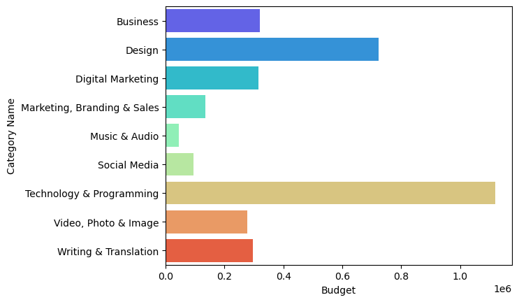

```python
Category_Name_group=df.groupby("Category Name")["Budget"].sum()
sns.barplot(x=Category_Name_group,y=Category_Name_group.index,palette="rainbow")
```

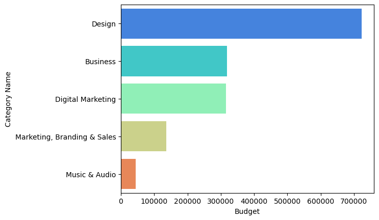

```python
lowest = Category_Name_group.head(5).sort_values(ascending=False)
sns.barplot(x=lowest,y=lowest.index,palette="rainbow")
```

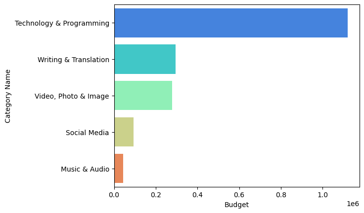

```python
Highest=Category_Name_group.tail(5).sort_values(ascending=False)
sns.barplot(x=Highest,y=Highest.index,palette="rainbow")
```

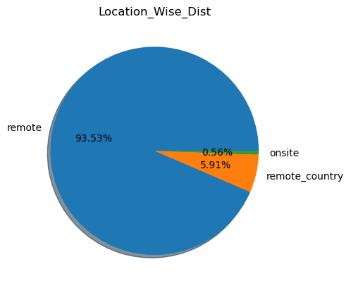

```python
location_counts=df["Location"].value_counts()
plt.pie(location_counts,labels=location_counts.index,autopct='%0.2f%%',shadow=True)
plt.title("Location_Wise_Dist")
plt.show()
```

From above graph we see that laocation wise distribution remote location has highest demand.

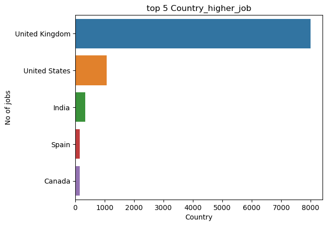

```python
top=df["Client Country"].value_counts().sort_values(ascending=False)
top_new=top.head(5)
sns.barplot(x=top_new.values,y=top_new.index)
plt.title("top 5 Country_higher_job")
plt.xlabel("Country")
plt.ylabel("No of jobs")
```

From above graph we see that there is high jobs in United Kingdom Followed by United States, India, Spain, canada.

[output not shown]

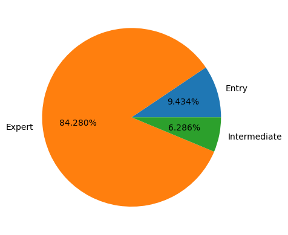

```python
Exp_group=df.groupby("Experience")["Budget"].sum()
ex=(0,0,0)
plt.pie(Exp_group,explode=ex,labels=Exp_group.index,autopct="%0.3f%%")
```

From above graph we see thatExpert level Experience needs Highest Budget.

[figure not shown]